# CMSC320 Final Project - Education Analysis

## Tutorial: Analysis of U.S. Education Data

Madalyn Maleh and Maryann Vazhapilly

16 December 2022

1. Introduction
2. Data Cleaning, Preparation, and Preprocessing
3. Exploratory Data Analysis and Visualizations
4. Prediction with Regression Models
5. Hypothesis Testing
6. Conclusion/Insights

## Introduction

### Motivation

Given that both of us are involved in education, one is double majoring in Human Development/Education and another is a computing instructor for CS outreach programs, we wanted to explore U.S. Education trends and examine what factors influence student educational experiences. We hoped to study the outcomes of these factors and look at what changes can and should be made.

In this tutorial, we will analyze U.S. Education data from 1992-2016 that consists of K-12 financial, enrollment, and achievement data, available through Kaggle from the Urban Institute [here](https://www.kaggle.com/datasets/noriuk/us-education-datasets-unification-project).

While it is not a secret that money has a dramatic impact on educational outcomes, we wanted to do an in-depth analysis to examine which categories of spending have the most pronounced effect and to understand just how much of student test scores can really be predicted by purely financial factors. Our dataset does not include information on the financial situations of individual students. Rather, we are looking at how accurately we can estimate scores based on statewide data about revenue and expenditure for each year.

We were also very interested in finding out how the predicting factors and the accuracy of the methods used vary for the different categories of scores included in the dataset. Namely, we wanted to find out if monetary factors were more predictive of test scores in one of either reading or math or alternatively in one grade level examined versus another.

### Required Libraries/Tools

The following libraries/tools were used throughout the project. They allowed us create visualizations, plot data for inference, create models to draw conclusions, and so much more! Their documentation is linked below:

- [pandas](https://pandas.pydata.org/pandas-docs/stable/index.html), contains data structures and data analysis tools
- [numpy](https://numpy.org/doc/stable/), a package for scientific computing with array objects and shape manipulation
- [matplotlib](https://matplotlib.org/stable/index.html), for creating visualizations
- [sklearn](https://scikit-learn.org/stable/index.html) for regressions, predictive data analysis, and modelling
- [scipy](https://docs.scipy.org/doc/scipy/) software for mathematics, statistics, and optimization

## Data Cleaning, Preparation, and Preprocessing

```python
import pandas as pd
data = pd.read_csv("states_all.csv", sep=',')
display(data)
```

|  | PRIMARY_KEY | STATE | YEAR | ENROLL | TOTAL_REVENUE | FEDERAL_REVENUE | STATE_REVENUE | LOCAL_REVENUE | TOTAL_EXPENDITURE | INSTRUCTION_EXPENDITURE | ... | GRADES_4_G | GRADES_8_G | GRADES_12_G | GRADES_1_8_G | GRADES_9_12_G | GRADES_ALL_G | AVG_MATH_4_SCORE | AVG_MATH_8_SCORE | AVG_READING_4_SCORE | AVG_READING_8_SCORE |
| --- | --- | --- | --- | --- | --- | --- | --- | --- | --- | --- | --- | --- | --- | --- | --- | --- | --- | --- | --- | --- | --- |
| 0 | 1992_ALABAMA | ALABAMA | 1992 | NaN | 2678885.0 | 304177.0 | 1659028.0 | 715680.0 | 2653798.0 | 1481703.0 | ... | 57948.0 | 58025.0 | 41167.0 | NaN | NaN | 731634.0 | 208.0 | 252.0 | 207.0 | NaN |
| 1 | 1992_ALASKA | ALASKA | 1992 | NaN | 1049591.0 | 106780.0 | 720711.0 | 222100.0 | 972488.0 | 498362.0 | ... | 9748.0 | 8789.0 | 6714.0 | NaN | NaN | 122487.0 | NaN | NaN | NaN | NaN |
| 2 | 1992_ARIZONA | ARIZONA | 1992 | NaN | 3258079.0 | 297888.0 | 1369815.0 | 1590376.0 | 3401580.0 | 1435908.0 | ... | 55433.0 | 49081.0 | 37410.0 | NaN | NaN | 673477.0 | 215.0 | 265.0 | 209.0 | NaN |
| 3 | 1992_ARKANSAS | ARKANSAS | 1992 | NaN | 1711959.0 | 178571.0 | 958785.0 | 574603.0 | 1743022.0 | 964323.0 | ... | 34632.0 | 36011.0 | 27651.0 | NaN | NaN | 441490.0 | 210.0 | 256.0 | 211.0 | NaN |
| 4 | 1992_CALIFORNIA | CALIFORNIA | 1992 | NaN | 26260025.0 | 2072470.0 | 16546514.0 | 7641041.0 | 27138832.0 | 14358922.0 | ... | 418418.0 | 363296.0 | 270675.0 | NaN | NaN | 5254844.0 | 208.0 | 261.0 | 202.0 | NaN |
| ... | ... | ... | ... | ... | ... | ... | ... | ... | ... | ... | ... | ... | ... | ... | ... | ... | ... | ... | ... | ... | ... |
| 1710 | 2019_VIRGINIA | VIRGINIA | 2019 | NaN | NaN | NaN | NaN | NaN | NaN | NaN | ... | NaN | NaN | NaN | NaN | NaN | NaN | 247.0 | 287.0 | 224.0 | 262.0 |
| 1711 | 2019_WASHINGTON | WASHINGTON | 2019 | NaN | NaN | NaN | NaN | NaN | NaN | NaN | ... | NaN | NaN | NaN | NaN | NaN | NaN | 240.0 | 286.0 | 220.0 | 266.0 |
| 1712 | 2019_WEST_VIRGINIA | WEST_VIRGINIA | 2019 | NaN | NaN | NaN | NaN | NaN | NaN | NaN | ... | NaN | NaN | NaN | NaN | NaN | NaN | 231.0 | 272.0 | 213.0 | 256.0 |
| 1713 | 2019_WISCONSIN | WISCONSIN | 2019 | NaN | NaN | NaN | NaN | NaN | NaN | NaN | ... | NaN | NaN | NaN | NaN | NaN | NaN | 242.0 | 289.0 | 220.0 | 267.0 |
| 1714 | 2019_WYOMING | WYOMING | 2019 | NaN | NaN | NaN | NaN | NaN | NaN | NaN | ... | NaN | NaN | NaN | NaN | NaN | NaN | 246.0 | 286.0 | 227.0 | 265.0 |

1715 rows × 25 columns

Below is a description of each column:

- PRIMARY_KEY: A unique identifier made from the year and state
- STATE: State
- YEAR: Year
- ENROLL: K-12 enrollment estimated by the US Census Bureau
- TOTAL_REVENUE: The total amount of revenue for the state in the given year
- FEDERAL_REVENUE: The amount of revenue the state receives from the federal government for educational purposes
- STATE_REVENUE: The amount of revenue generated by the state for use in education
- LOCAL_REVENUE: The total amount of revenue generated by local jurisdictions and municipalities for use in education
- TOTAL_EXPENDITURE: The total amount of money spent on education-related purposes
- INSTRUCTIONAL_EXPENDITURE: The amount of money spent directly on the student's indstruction (teacher salaries, textbooks, etc.)
- SUPPORT_SERVICES_EXPENDITURE: The amount of money spent on non-academic services meant to support the students (school counselors, health centers)
- OTHER_EXPENDITURE: The amount of money spent on miscellaneous costs not covered by other categories
- CAPITAL_OUTLAY_EXPENDITURE: The amount of money spent on maintaining capital assets
- GRADES_PK_G: pre-K enrollment
- GRADES_4_G: 4th grade enrollment
- GRADES_8_G: 8th grade enrollment
- GRADES_12_G: 12th grade enrollment
- GRADES_1_8_G: 1st-8th grade enrollment
- GRADES_9_12_G: 9th-12th grade enrollment
- GRADES_ALL_G: Total K-12 enrollment
- AVG_MATH_4_SCORE: Average 4th grade math score
- AVG_MATH_8_SCORE: Average 8th grade math score
- AVG_READING_4_SCORE: Average 4th grade reading score
- AVG_READING_8_SCORE: Average 8th grade reading score

The ENROLL column seen above tracks the total enrollment as estimated by the US Census Bureau for the given state and year, while the GRADES_ALL_G column tracks the total enrollment as estimated by the National Center for Education Statistics. Since these two columns are estimating the same quantity, we decided to reduce them down to one to limit [covariance](https://www.statisticshowto.com/probability-and-statistics/statistics-definitions/covariance/) in the data. [This article](https://statisticsbyjim.com/regression/multicollinearity-in-regression-analysis/) walks through the potential problems that can arise in machine learning models from covariance, namely the decreased precision in the estimates of the coefficients and the reliability of the p-values. To condense the two columns into one, we first calculated the number of missing values in each column to see if one of the columns is significantly more populated than the other.

```python
import numpy as np

# Finding how many entries for both of the columns are represented by NaN in the data.
num_missing_in_enroll = len(data[np.isnan(data['ENROLL'])])
num_missing_in_grades_all_g = len(data[np.isnan(data['GRADES_ALL_G'])])

print("Number of missing values in the ENROLL column: ", num_missing_in_enroll)
print("Number of missing values in the GRADES_ALL_G column: ", num_missing_in_grades_all_g)
```

```
Number of missing values in the ENROLL column:  491
Number of missing values in the GRADES_ALL_G column:  83
```

The GRADES_ALL_G column has less missing values at 83 compared to 491, but 83 is still a significant number of rows. We then decided to find out how much overlap there is between the rows that have missing values for each of the columns.

```python
# Create separate dataframes with the rows that are missing values in each of the columns.
missing_rows_in_enroll = data[np.isnan(data['ENROLL'])]
missing_rows_in_grades_all_g = data[np.isnan(data['GRADES_ALL_G'])]

# Merge the two dataframes, keeping only the rows that appear in both.
num_missing_in_both = len(pd.merge(missing_rows_in_enroll, missing_rows_in_grades_all_g))

# Find the number of rows that have a missing value in the ENROLL column with an identifier PRIMARY_KEY that is not present in the
# dataframe that contains the rows missing a value in the GRADES_ALL_G column.
num_missing_only_in_enroll = len(missing_rows_in_enroll[~missing_rows_in_enroll.PRIMARY_KEY.isin(missing_rows_in_grades_all_g.PRIMARY_KEY)])

# Find the number of rows that have a missing value in the GRADES_ALL_G column with an identifier PRIMARY_KEY that is not present in the
# dataframe that contains the rows missing a value in the ENROLL column.
num_missing_only_in_grades_all_g = len(missing_rows_in_grades_all_g[~missing_rows_in_grades_all_g.PRIMARY_KEY.isin(missing_rows_in_enroll.PRIMARY_KEY)])

print("Number of rows missing values in both columns: ", num_missing_in_both)
print("Number of rows missing values only in the ENROLL column: ", num_missing_only_in_enroll)
print("Number of rows missing values only in the GRADES_ALL_G column: ", num_missing_only_in_grades_all_g)
```

```
Number of rows missing values in both columns:  83
Number of rows missing values only in the ENROLL column:  408
Number of rows missing values only in the GRADES_ALL_G column:  0
```

We can see that the 83 rows found earlier to be missing a value in the GRADES_ALL_G column are all also missing a value in the ENROLL column. We debated a number of approaches to fill in the missing data for these 83 rows. We decided that if these rows were clustered together in the original data (close in year), we would construct linear models for each state that predict the enrollment based on the trend in the available data. On the other hand, if the rows were spread out across the dataset, we would estimate the enrollment numbers for a state and year with missing data by taking the average of the numbers from the year before and after, or a weighted average by how far away the reference years are to the year we are estimating if the years directly next to it for the same state have a missing value as well. [This article](https://www.theanalysisfactor.com/seven-ways-to-make-up-data-common-methods-to-imputing-missing-data/) provides a lot of useful information on different methods of imputation and best use cases for each.

```python
# Prints the rows that have missing enrollment numbers in both columns (same as in just GRADES_ALL_G).
display(missing_rows_in_grades_all_g)
```

|  | PRIMARY_KEY | STATE | YEAR | ENROLL | TOTAL_REVENUE | FEDERAL_REVENUE | STATE_REVENUE | LOCAL_REVENUE | TOTAL_EXPENDITURE | INSTRUCTION_EXPENDITURE | ... | GRADES_4_G | GRADES_8_G | GRADES_12_G | GRADES_1_8_G | GRADES_9_12_G | GRADES_ALL_G | AVG_MATH_4_SCORE | AVG_MATH_8_SCORE | AVG_READING_4_SCORE | AVG_READING_8_SCORE |
| --- | --- | --- | --- | --- | --- | --- | --- | --- | --- | --- | --- | --- | --- | --- | --- | --- | --- | --- | --- | --- | --- |
| 1632 | 1990_DODEA | DODEA | 1990 | NaN | NaN | NaN | NaN | NaN | NaN | NaN | ... | NaN | NaN | NaN | NaN | NaN | NaN | NaN | NaN | NaN | NaN |
| 1633 | 1990_NATIONAL | NATIONAL | 1990 | NaN | NaN | NaN | NaN | NaN | NaN | NaN | ... | NaN | NaN | NaN | NaN | NaN | NaN | 213.0 | 263.0 | NaN | NaN |
| 1634 | 1992_DODEA | DODEA | 1992 | NaN | NaN | NaN | NaN | NaN | NaN | NaN | ... | NaN | NaN | NaN | NaN | NaN | NaN | NaN | NaN | NaN | NaN |
| 1635 | 1992_NATIONAL | NATIONAL | 1992 | NaN | NaN | NaN | NaN | NaN | NaN | NaN | ... | NaN | NaN | NaN | NaN | NaN | NaN | 220.0 | 268.0 | 217.0 | 260.0 |
| 1636 | 1994_DODEA | DODEA | 1994 | NaN | NaN | NaN | NaN | NaN | NaN | NaN | ... | NaN | NaN | NaN | NaN | NaN | NaN | NaN | NaN | NaN | NaN |
| ... | ... | ... | ... | ... | ... | ... | ... | ... | ... | ... | ... | ... | ... | ... | ... | ... | ... | ... | ... | ... | ... |
| 1710 | 2019_VIRGINIA | VIRGINIA | 2019 | NaN | NaN | NaN | NaN | NaN | NaN | NaN | ... | NaN | NaN | NaN | NaN | NaN | NaN | 247.0 | 287.0 | 224.0 | 262.0 |
| 1711 | 2019_WASHINGTON | WASHINGTON | 2019 | NaN | NaN | NaN | NaN | NaN | NaN | NaN | ... | NaN | NaN | NaN | NaN | NaN | NaN | 240.0 | 286.0 | 220.0 | 266.0 |
| 1712 | 2019_WEST_VIRGINIA | WEST_VIRGINIA | 2019 | NaN | NaN | NaN | NaN | NaN | NaN | NaN | ... | NaN | NaN | NaN | NaN | NaN | NaN | 231.0 | 272.0 | 213.0 | 256.0 |
| 1713 | 2019_WISCONSIN | WISCONSIN | 2019 | NaN | NaN | NaN | NaN | NaN | NaN | NaN | ... | NaN | NaN | NaN | NaN | NaN | NaN | 242.0 | 289.0 | 220.0 | 267.0 |
| 1714 | 2019_WYOMING | WYOMING | 2019 | NaN | NaN | NaN | NaN | NaN | NaN | NaN | ... | NaN | NaN | NaN | NaN | NaN | NaN | 246.0 | 286.0 | 227.0 | 265.0 |

83 rows × 25 columns

Upon manual inspection, we can see that the rows with missing values in the enrollment columns also have missing values in many unrelated columns. We wanted to confirm that this was true with all of these rows and not just the few that are shown in the preview above.

```python
num_columns = len(data.columns)

# Make a list with an entry for each row that corresponds to its number of missing entries.
num_missing = []
for index, row in missing_rows_in_grades_all_g.iterrows():
    # Count the number of missing entries by iterating through each column.
    count = 0
    # Start with index 2 because the first two columns are non-numeric data and are present for all rows.
    for col in range(2, num_columns):
        if np.isnan(row[col]):
            count += 1
    num_missing.append(count)

print("Total number of columns: ", num_columns)
print("Minimum number of columns missing given that both enrollment columns are missing: ", min(num_missing), "\n")

print("Total number of rows: ", len(data), "\n")
```

```
Total number of columns:  25
Minimum number of columns missing given that both enrollment columns are missing:  18

Total number of rows:  1715
```

Since these rows all have at least 18 columns missing, we decided to eliminate them entirely. [This article](https://medium.com/mlearning-ai/the-importance-of-deleting-columns-with-null-values-when-making-predictions-127a58adb8cb) outlines many of the justifications for when and why it might be necessary to remove entries with an excess number of missing values and was very helpful in our decision. Generally speaking, our goal is to analyze the effects of expenditure on student test scores rather than just scores over time, so rows that are missing all of the expenditure data are not helpful even if they include some scoring information.

```python
# Keeping the rows in the original data that do not have a match in the dataframe of rows with missing enrollment values.
original_data = data.copy()
data = data[~data.PRIMARY_KEY.isin(missing_rows_in_grades_all_g.PRIMARY_KEY)]
display(data)
```

|  | PRIMARY_KEY | STATE | YEAR | ENROLL | TOTAL_REVENUE | FEDERAL_REVENUE | STATE_REVENUE | LOCAL_REVENUE | TOTAL_EXPENDITURE | INSTRUCTION_EXPENDITURE | ... | GRADES_4_G | GRADES_8_G | GRADES_12_G | GRADES_1_8_G | GRADES_9_12_G | GRADES_ALL_G | AVG_MATH_4_SCORE | AVG_MATH_8_SCORE | AVG_READING_4_SCORE | AVG_READING_8_SCORE |
| --- | --- | --- | --- | --- | --- | --- | --- | --- | --- | --- | --- | --- | --- | --- | --- | --- | --- | --- | --- | --- | --- |
| 0 | 1992_ALABAMA | ALABAMA | 1992 | NaN | 2678885.0 | 304177.0 | 1659028.0 | 715680.0 | 2653798.0 | 1481703.0 | ... | 57948.0 | 58025.0 | 41167.0 | NaN | NaN | 731634.0 | 208.0 | 252.0 | 207.0 | NaN |
| 1 | 1992_ALASKA | ALASKA | 1992 | NaN | 1049591.0 | 106780.0 | 720711.0 | 222100.0 | 972488.0 | 498362.0 | ... | 9748.0 | 8789.0 | 6714.0 | NaN | NaN | 122487.0 | NaN | NaN | NaN | NaN |
| 2 | 1992_ARIZONA | ARIZONA | 1992 | NaN | 3258079.0 | 297888.0 | 1369815.0 | 1590376.0 | 3401580.0 | 1435908.0 | ... | 55433.0 | 49081.0 | 37410.0 | NaN | NaN | 673477.0 | 215.0 | 265.0 | 209.0 | NaN |
| 3 | 1992_ARKANSAS | ARKANSAS | 1992 | NaN | 1711959.0 | 178571.0 | 958785.0 | 574603.0 | 1743022.0 | 964323.0 | ... | 34632.0 | 36011.0 | 27651.0 | NaN | NaN | 441490.0 | 210.0 | 256.0 | 211.0 | NaN |
| 4 | 1992_CALIFORNIA | CALIFORNIA | 1992 | NaN | 26260025.0 | 2072470.0 | 16546514.0 | 7641041.0 | 27138832.0 | 14358922.0 | ... | 418418.0 | 363296.0 | 270675.0 | NaN | NaN | 5254844.0 | 208.0 | 261.0 | 202.0 | NaN |
| ... | ... | ... | ... | ... | ... | ... | ... | ... | ... | ... | ... | ... | ... | ... | ... | ... | ... | ... | ... | ... | ... |
| 1627 | 1988_WYOMING | WYOMING | 1988 | NaN | NaN | NaN | NaN | NaN | NaN | NaN | ... | 8007.0 | 7158.0 | 6753.0 | NaN | NaN | 97793.0 | NaN | NaN | NaN | NaN |
| 1628 | 1989_WYOMING | WYOMING | 1989 | NaN | NaN | NaN | NaN | NaN | NaN | NaN | ... | 8126.0 | 6959.0 | 6281.0 | NaN | NaN | 97172.0 | NaN | NaN | NaN | NaN |
| 1629 | 1990_WYOMING | WYOMING | 1990 | NaN | NaN | NaN | NaN | NaN | NaN | NaN | ... | 7935.0 | 7376.0 | 6245.0 | NaN | NaN | 98226.0 | NaN | 272.0 | NaN | NaN |
| 1630 | 1991_WYOMING | WYOMING | 1991 | NaN | NaN | NaN | NaN | NaN | NaN | NaN | ... | 8269.0 | 7511.0 | 6425.0 | NaN | NaN | 102074.0 | NaN | NaN | NaN | NaN |
| 1631 | 2017_WYOMING | WYOMING | 2017 | NaN | NaN | NaN | NaN | NaN | NaN | NaN | ... | 7537.0 | 7086.0 | 6405.0 | NaN | 27361.0 | 94258.0 | 248.0 | 289.0 | 227.0 | 269.0 |

1632 rows × 25 columns

Even with eliminating the rows with missing enrollment values, we can see from the updated dataframe above that there are still rows with many columns missing. We decided to calculate the distribution of missing columns in the remaining rows so that we can set an appropriate threshold for the number of missing values that warrants dropping the row.

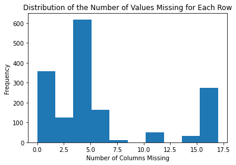

```python
# Make a list with an entry for each row that corresponds to its number of missing entries.
num_missing = []
for index, row in data.iterrows():
    # Count the number of missing entries by iterating through each column.
    count = 0
    # Start with index 2 because the first two columns are non-numeric data and are present for all rows.
    for col in range(2, num_columns):
        if np.isnan(row[col]):
            count += 1
    num_missing.append(count)

# Make a histogram that shows the distribution of missing values.
import matplotlib.pyplot as plt

plt.hist(num_missing)
plt.xlabel('Number of Columns Missing');
plt.ylabel('Frequency')
plt.title('Distribution of the Number of Values Missing for Each Row')
plt.show()
```

From the histogram above, we can see that the majority of the data is clumped together from 0-7 values missing. We decided to drop any columns that are beyond this point since they have a significant number of missing values that are difficult to estimate from the other values because they are increasingly likely to be missing as well.

```python
# Creating a temporary column in the dataframe that contains the number of missing values for the remaining rows.
data = data.copy()

# Keeping only the rows with no more than 7 missing values.
data['num_missing'] = num_missing
data = data[data['num_missing'] <= 7]
```

Back to the enrollment columns, some rows will still be missing values in the ENROLL column, but all values should be present in the GRADES_ALL_G column. We thus decided to exlcusively use the values from the GRADES_ALL_G column rather than taking an average so that the method of calculation can be consistent for each row. [This article](https://towardsdatascience.com/the-ultimate-guide-to-data-cleaning-3969843991d4) explains the importance of handling missing values in a way that does not introduce any new variation into the data. We did not want to factor in the values from the ENROLL column where applicable since we could not do this for every row, and we did not want to further bias the data.

```python
# Drops the ENROLL column and the temporary column num_missing created to aid in filtering.
data = data.drop(['ENROLL', 'num_missing'], axis=1)
display(data)
```

|  | PRIMARY_KEY | STATE | YEAR | TOTAL_REVENUE | FEDERAL_REVENUE | STATE_REVENUE | LOCAL_REVENUE | TOTAL_EXPENDITURE | INSTRUCTION_EXPENDITURE | SUPPORT_SERVICES_EXPENDITURE | ... | GRADES_4_G | GRADES_8_G | GRADES_12_G | GRADES_1_8_G | GRADES_9_12_G | GRADES_ALL_G | AVG_MATH_4_SCORE | AVG_MATH_8_SCORE | AVG_READING_4_SCORE | AVG_READING_8_SCORE |
| --- | --- | --- | --- | --- | --- | --- | --- | --- | --- | --- | --- | --- | --- | --- | --- | --- | --- | --- | --- | --- | --- |
| 0 | 1992_ALABAMA | ALABAMA | 1992 | 2678885.0 | 304177.0 | 1659028.0 | 715680.0 | 2653798.0 | 1481703.0 | 735036.0 | ... | 57948.0 | 58025.0 | 41167.0 | NaN | NaN | 731634.0 | 208.0 | 252.0 | 207.0 | NaN |
| 2 | 1992_ARIZONA | ARIZONA | 1992 | 3258079.0 | 297888.0 | 1369815.0 | 1590376.0 | 3401580.0 | 1435908.0 | 1007732.0 | ... | 55433.0 | 49081.0 | 37410.0 | NaN | NaN | 673477.0 | 215.0 | 265.0 | 209.0 | NaN |
| 3 | 1992_ARKANSAS | ARKANSAS | 1992 | 1711959.0 | 178571.0 | 958785.0 | 574603.0 | 1743022.0 | 964323.0 | 483488.0 | ... | 34632.0 | 36011.0 | 27651.0 | NaN | NaN | 441490.0 | 210.0 | 256.0 | 211.0 | NaN |
| 4 | 1992_CALIFORNIA | CALIFORNIA | 1992 | 26260025.0 | 2072470.0 | 16546514.0 | 7641041.0 | 27138832.0 | 14358922.0 | 8520926.0 | ... | 418418.0 | 363296.0 | 270675.0 | NaN | NaN | 5254844.0 | 208.0 | 261.0 | 202.0 | NaN |
| 5 | 1992_COLORADO | COLORADO | 1992 | 3185173.0 | 163253.0 | 1307986.0 | 1713934.0 | 3264826.0 | 1642466.0 | 1035970.0 | ... | 50648.0 | 45025.0 | 34533.0 | NaN | NaN | 612635.0 | 221.0 | 272.0 | 217.0 | NaN |
| ... | ... | ... | ... | ... | ... | ... | ... | ... | ... | ... | ... | ... | ... | ... | ... | ... | ... | ... | ... | ... | ... |
| 1270 | 2016_VIRGINIA | VIRGINIA | 2016 | 16259274.0 | 1058146.0 | 6297587.0 | 8903541.0 | 16497520.0 | 8944614.0 | 5164699.0 | ... | 99258.0 | 95234.0 | 90500.0 | 773615.0 | 389330.0 | 1287026.0 | NaN | NaN | NaN | NaN |
| 1271 | 2016_WASHINGTON | WASHINGTON | 2016 | 14964364.0 | 1097684.0 | 9211201.0 | 4655479.0 | 15253296.0 | 7087365.0 | 4904575.0 | ... | 86114.0 | 81039.0 | 90645.0 | 667327.0 | 339349.0 | 1101711.0 | NaN | NaN | NaN | NaN |
| 1272 | 2016_WEST_VIRGINIA | WEST_VIRGINIA | 2016 | 3391579.0 | 358068.0 | 1863062.0 | 1170449.0 | 3366566.0 | 1804235.0 | 1127255.0 | ... | 20324.0 | 19931.0 | 18155.0 | 159595.0 | 79442.0 | 273855.0 | NaN | NaN | NaN | NaN |
| 1273 | 2016_WISCONSIN | WISCONSIN | 2016 | 11697466.0 | 782610.0 | 5986763.0 | 4928093.0 | 11787535.0 | 5760418.0 | 3691439.0 | ... | 62408.0 | 61432.0 | 66303.0 | 488983.0 | 262681.0 | 864432.0 | NaN | NaN | NaN | NaN |
| 1274 | 2016_WYOMING | WYOMING | 2016 | 2044669.0 | 123012.0 | 1175899.0 | 745758.0 | 2034229.0 | 921494.0 | 585700.0 | ... | 7642.0 | 7135.0 | 6262.0 | 58998.0 | 26924.0 | 94170.0 | NaN | NaN | NaN | NaN |

1266 rows × 24 columns

We then decided to examine the rest of the columns in the dataset to see how to address their missing values, if any.

```python
# Print the number of missing values for each column.
data.isna().sum()
```

```
PRIMARY_KEY                       0
STATE                             0
YEAR                              0
TOTAL_REVENUE                     0
FEDERAL_REVENUE                   0
STATE_REVENUE                     0
LOCAL_REVENUE                     0
TOTAL_EXPENDITURE                 0
INSTRUCTION_EXPENDITURE           0
SUPPORT_SERVICES_EXPENDITURE      0
OTHER_EXPENDITURE                42
CAPITAL_OUTLAY_EXPENDITURE        0
GRADES_PK_G                      13
GRADES_KG_G                       0
GRADES_4_G                        0
GRADES_8_G                        0
GRADES_12_G                       0
GRADES_1_8_G                    246
GRADES_9_12_G                   246
GRADES_ALL_G                      0
AVG_MATH_4_SCORE                826
AVG_MATH_8_SCORE                827
AVG_READING_4_SCORE             743
AVG_READING_8_SCORE             830
dtype: int64
```

Starting with the last 4 columns indicating the average test scores, we can see that there are a significant number of missing rows. We first wanted to look for how many rows were missing values in all 4 columns.

```python
# Check which rows have NaN in all 4 of the score columns.
num_rows_without_scores = 0
for index, row in data.iterrows():
    if np.isnan(row['AVG_MATH_4_SCORE']) & np.isnan(row['AVG_MATH_8_SCORE']) & np.isnan(row['AVG_READING_4_SCORE']) & np.isnan(row['AVG_READING_8_SCORE']):
        num_rows_without_scores += 1
print("Number of rows without score data: ", num_rows_without_scores)
```

```
Number of rows without score data:  702
```

```python
pd.set_option('mode.chained_assignment', None)

score_col_names = ['AVG_MATH_4_SCORE', 'AVG_MATH_8_SCORE', 'AVG_READING_4_SCORE', 'AVG_READING_8_SCORE']
for col in score_col_names:

    for index, row in data.iterrows():
        if np.isnan(row[col]):
            year = row['YEAR']
            state = row['STATE']

            # Find the closest years before and after the given year for the state.
            earlier_rows = original_data[(original_data['STATE'] == state) & (original_data['YEAR'] <= year) & (original_data[col].notna())]
            later_rows = original_data[(original_data['STATE'] == state) & (original_data['YEAR'] >= year) & (original_data[col].notna())]

            # If there are years for the state before this year, record the closest.
            if len(earlier_rows) > 0:
                earlier_index_closest = np.argmax(earlier_rows['YEAR'])
                before = earlier_rows.iloc[earlier_index_closest]

                # Value present before and after. Take the weighted average based on how close the years are
                # to the year we are estimating.
                if len(later_rows) > 0:
                    later_index_closest = np.argmin(later_rows['YEAR'])
                    after = later_rows.iloc[later_index_closest]

                    diff_before = year - before['YEAR']
                    diff_after = after['YEAR'] - year

                    # Handles the potential case where the value is filled in for the original data but not
                    # since some of the rows have been removed.
                    if diff_before == 0:
                        data[col] = before[col]
                    elif diff_after == 0:
                        data[col] = after[col]
                    else:
                        data.loc[index, col] = (diff_before * before[col] + diff_after * after[col]) / (diff_before + diff_after)

                # If there is a value for a year before but not after, use the value from the year before.
                else:
                    data.loc[index, col] = before[col]
            # If there is a value for a year after but not before, use the value from the year after.
            elif len(later_rows) > 0:
                data.loc[index, col] = after[col]
display(data)
```

|  | PRIMARY_KEY | STATE | YEAR | TOTAL_REVENUE | FEDERAL_REVENUE | STATE_REVENUE | LOCAL_REVENUE | TOTAL_EXPENDITURE | INSTRUCTION_EXPENDITURE | SUPPORT_SERVICES_EXPENDITURE | ... | GRADES_4_G | GRADES_8_G | GRADES_12_G | GRADES_1_8_G | GRADES_9_12_G | GRADES_ALL_G | AVG_MATH_4_SCORE | AVG_MATH_8_SCORE | AVG_READING_4_SCORE | AVG_READING_8_SCORE |
| --- | --- | --- | --- | --- | --- | --- | --- | --- | --- | --- | --- | --- | --- | --- | --- | --- | --- | --- | --- | --- | --- |
| 0 | 1992_ALABAMA | ALABAMA | 1992 | 2678885.0 | 304177.0 | 1659028.0 | 715680.0 | 2653798.0 | 1481703.0 | 735036.0 | ... | 57948.0 | 58025.0 | 41167.0 | NaN | NaN | 731634.0 | 208.0 | 252.0 | 207.0 | 269.0 |
| 2 | 1992_ARIZONA | ARIZONA | 1992 | 3258079.0 | 297888.0 | 1369815.0 | 1590376.0 | 3401580.0 | 1435908.0 | 1007732.0 | ... | 55433.0 | 49081.0 | 37410.0 | NaN | NaN | 673477.0 | 215.0 | 265.0 | 209.0 | 269.0 |
| 3 | 1992_ARKANSAS | ARKANSAS | 1992 | 1711959.0 | 178571.0 | 958785.0 | 574603.0 | 1743022.0 | 964323.0 | 483488.0 | ... | 34632.0 | 36011.0 | 27651.0 | NaN | NaN | 441490.0 | 210.0 | 256.0 | 211.0 | 269.0 |
| 4 | 1992_CALIFORNIA | CALIFORNIA | 1992 | 26260025.0 | 2072470.0 | 16546514.0 | 7641041.0 | 27138832.0 | 14358922.0 | 8520926.0 | ... | 418418.0 | 363296.0 | 270675.0 | NaN | NaN | 5254844.0 | 208.0 | 261.0 | 202.0 | 269.0 |
| 5 | 1992_COLORADO | COLORADO | 1992 | 3185173.0 | 163253.0 | 1307986.0 | 1713934.0 | 3264826.0 | 1642466.0 | 1035970.0 | ... | 50648.0 | 45025.0 | 34533.0 | NaN | NaN | 612635.0 | 221.0 | 272.0 | 217.0 | 269.0 |
| ... | ... | ... | ... | ... | ... | ... | ... | ... | ... | ... | ... | ... | ... | ... | ... | ... | ... | ... | ... | ... | ... |
| 1270 | 2016_VIRGINIA | VIRGINIA | 2016 | 16259274.0 | 1058146.0 | 6297587.0 | 8903541.0 | 16497520.0 | 8944614.0 | 5164699.0 | ... | 99258.0 | 95234.0 | 90500.0 | 773615.0 | 389330.0 | 1287026.0 | 247.5 | 289.0 | 228.5 | 267.5 |
| 1271 | 2016_WASHINGTON | WASHINGTON | 2016 | 14964364.0 | 1097684.0 | 9211201.0 | 4655479.0 | 15253296.0 | 7087365.0 | 4904575.0 | ... | 86114.0 | 81039.0 | 90645.0 | 667327.0 | 339349.0 | 1101711.0 | 243.5 | 288.0 | 224.5 | 269.5 |
| 1272 | 2016_WEST_VIRGINIA | WEST_VIRGINIA | 2016 | 3391579.0 | 358068.0 | 1863062.0 | 1170449.0 | 3366566.0 | 1804235.0 | 1127255.0 | ... | 20324.0 | 19931.0 | 18155.0 | 159595.0 | 79442.0 | 273855.0 | 235.5 | 272.0 | 216.5 | 259.5 |
| 1273 | 2016_WISCONSIN | WISCONSIN | 2016 | 11697466.0 | 782610.0 | 5986763.0 | 4928093.0 | 11787535.0 | 5760418.0 | 3691439.0 | ... | 62408.0 | 61432.0 | 66303.0 | 488983.0 | 262681.0 | 864432.0 | 241.5 | 288.5 | 221.5 | 269.5 |
| 1274 | 2016_WYOMING | WYOMING | 2016 | 2044669.0 | 123012.0 | 1175899.0 | 745758.0 | 2034229.0 | 921494.0 | 585700.0 | ... | 7642.0 | 7135.0 | 6262.0 | 58998.0 | 26924.0 | 94170.0 | 247.5 | 288.0 | 227.5 | 269.0 |

1266 rows × 24 columns

```python
# Print the number of missing values for each column.
data.isna().sum()
```

```
PRIMARY_KEY                       0
STATE                             0
YEAR                              0
TOTAL_REVENUE                     0
FEDERAL_REVENUE                   0
STATE_REVENUE                     0
LOCAL_REVENUE                     0
TOTAL_EXPENDITURE                 0
INSTRUCTION_EXPENDITURE           0
SUPPORT_SERVICES_EXPENDITURE      0
OTHER_EXPENDITURE                42
CAPITAL_OUTLAY_EXPENDITURE        0
GRADES_PK_G                      13
GRADES_KG_G                       0
GRADES_4_G                        0
GRADES_8_G                        0
GRADES_12_G                       0
GRADES_1_8_G                    246
GRADES_9_12_G                   246
GRADES_ALL_G                      0
AVG_MATH_4_SCORE                  0
AVG_MATH_8_SCORE                  0
AVG_READING_4_SCORE               0
AVG_READING_8_SCORE               0
dtype: int64
```

There are 246 missing values in the enrollment columns for grades 1-8 and grades 9-12. Although it is possible to fill in these values, we ultimately decided to remove both of these columns since the scores we are attempting to predict are specifically for 4th and 8th grade. It follows that enrollment in grades 9-12 it outside of the scope of our analysis, and we have other columns indicating the enrollment specifically for 4th and 8th grade without any missing values, so we will not be using the data that combines grades 1-8.

```python
data = data.drop(['GRADES_1_8_G', 'GRADES_9_12_G'], axis=1)
display(data)
```

|  | PRIMARY_KEY | STATE | YEAR | TOTAL_REVENUE | FEDERAL_REVENUE | STATE_REVENUE | LOCAL_REVENUE | TOTAL_EXPENDITURE | INSTRUCTION_EXPENDITURE | SUPPORT_SERVICES_EXPENDITURE | ... | GRADES_PK_G | GRADES_KG_G | GRADES_4_G | GRADES_8_G | GRADES_12_G | GRADES_ALL_G | AVG_MATH_4_SCORE | AVG_MATH_8_SCORE | AVG_READING_4_SCORE | AVG_READING_8_SCORE |
| --- | --- | --- | --- | --- | --- | --- | --- | --- | --- | --- | --- | --- | --- | --- | --- | --- | --- | --- | --- | --- | --- |
| 0 | 1992_ALABAMA | ALABAMA | 1992 | 2678885.0 | 304177.0 | 1659028.0 | 715680.0 | 2653798.0 | 1481703.0 | 735036.0 | ... | 8224.0 | 55460.0 | 57948.0 | 58025.0 | 41167.0 | 731634.0 | 208.0 | 252.0 | 207.0 | 269.0 |
| 2 | 1992_ARIZONA | ARIZONA | 1992 | 3258079.0 | 297888.0 | 1369815.0 | 1590376.0 | 3401580.0 | 1435908.0 | 1007732.0 | ... | 2544.0 | 53497.0 | 55433.0 | 49081.0 | 37410.0 | 673477.0 | 215.0 | 265.0 | 209.0 | 269.0 |
| 3 | 1992_ARKANSAS | ARKANSAS | 1992 | 1711959.0 | 178571.0 | 958785.0 | 574603.0 | 1743022.0 | 964323.0 | 483488.0 | ... | 808.0 | 33511.0 | 34632.0 | 36011.0 | 27651.0 | 441490.0 | 210.0 | 256.0 | 211.0 | 269.0 |
| 4 | 1992_CALIFORNIA | CALIFORNIA | 1992 | 26260025.0 | 2072470.0 | 16546514.0 | 7641041.0 | 27138832.0 | 14358922.0 | 8520926.0 | ... | 59067.0 | 431763.0 | 418418.0 | 363296.0 | 270675.0 | 5254844.0 | 208.0 | 261.0 | 202.0 | 269.0 |
| 5 | 1992_COLORADO | COLORADO | 1992 | 3185173.0 | 163253.0 | 1307986.0 | 1713934.0 | 3264826.0 | 1642466.0 | 1035970.0 | ... | 7410.0 | 47588.0 | 50648.0 | 45025.0 | 34533.0 | 612635.0 | 221.0 | 272.0 | 217.0 | 269.0 |
| ... | ... | ... | ... | ... | ... | ... | ... | ... | ... | ... | ... | ... | ... | ... | ... | ... | ... | ... | ... | ... | ... |
| 1270 | 2016_VIRGINIA | VIRGINIA | 2016 | 16259274.0 | 1058146.0 | 6297587.0 | 8903541.0 | 16497520.0 | 8944614.0 | 5164699.0 | ... | 33281.0 | 90800.0 | 99258.0 | 95234.0 | 90500.0 | 1287026.0 | 247.5 | 289.0 | 228.5 | 267.5 |
| 1271 | 2016_WASHINGTON | WASHINGTON | 2016 | 14964364.0 | 1097684.0 | 9211201.0 | 4655479.0 | 15253296.0 | 7087365.0 | 4904575.0 | ... | 13933.0 | 81102.0 | 86114.0 | 81039.0 | 90645.0 | 1101711.0 | 243.5 | 288.0 | 224.5 | 269.5 |
| 1272 | 2016_WEST_VIRGINIA | WEST_VIRGINIA | 2016 | 3391579.0 | 358068.0 | 1863062.0 | 1170449.0 | 3366566.0 | 1804235.0 | 1127255.0 | ... | 14949.0 | 19869.0 | 20324.0 | 19931.0 | 18155.0 | 273855.0 | 235.5 | 272.0 | 216.5 | 259.5 |
| 1273 | 2016_WISCONSIN | WISCONSIN | 2016 | 11697466.0 | 782610.0 | 5986763.0 | 4928093.0 | 11787535.0 | 5760418.0 | 3691439.0 | ... | 55436.0 | 57332.0 | 62408.0 | 61432.0 | 66303.0 | 864432.0 | 241.5 | 288.5 | 221.5 | 269.5 |
| 1274 | 2016_WYOMING | WYOMING | 2016 | 2044669.0 | 123012.0 | 1175899.0 | 745758.0 | 2034229.0 | 921494.0 | 585700.0 | ... | 664.0 | 7584.0 | 7642.0 | 7135.0 | 6262.0 | 94170.0 | 247.5 | 288.0 | 227.5 | 269.0 |

1266 rows × 22 columns

```python
# Print the number of missing values for each column.
data.isna().sum()
```

```
PRIMARY_KEY                      0
STATE                            0
YEAR                             0
TOTAL_REVENUE                    0
FEDERAL_REVENUE                  0
STATE_REVENUE                    0
LOCAL_REVENUE                    0
TOTAL_EXPENDITURE                0
INSTRUCTION_EXPENDITURE          0
SUPPORT_SERVICES_EXPENDITURE     0
OTHER_EXPENDITURE               42
CAPITAL_OUTLAY_EXPENDITURE       0
GRADES_PK_G                     13
GRADES_KG_G                      0
GRADES_4_G                       0
GRADES_8_G                       0
GRADES_12_G                      0
GRADES_ALL_G                     0
AVG_MATH_4_SCORE                 0
AVG_MATH_8_SCORE                 0
AVG_READING_4_SCORE              0
AVG_READING_8_SCORE              0
dtype: int64
```

There are 13 missing values for the pre-K enrollment column. Upon manual inspection of the data, we can see that 10 of these 13 values are in Wyoming for the rows remaining.

```python
# Show all entires for Wyoming.
wyoming = data[data['STATE'] == 'WYOMING']['GRADES_PK_G']
display(wyoming)
```

```
50         NaN
101        NaN
152        NaN
203        NaN
254        NaN
305        NaN
356        NaN
407        NaN
458        NaN
509        NaN
560     1668.0
611     2184.0
662      374.0
713      439.0
764      423.0
815      413.0
866      452.0
917      534.0
968      582.0
1019     518.0
1070     540.0
1121     514.0
1172     564.0
1223     509.0
1274     664.0
Name: GRADES_PK_G, dtype: float64
```

These 10 rows are difficult to fill in using other data from Wyoming since they are all clustered together at the beginning of the time period, and there also seems to be a noticeable dropoff in values 2 years later. There are many different possibilities for what the trend could have been in this time, and it is hard to predict a general range of values. We thus decided to fill in the missing entries with the mean for the given year. [This article](https://www.sciencedirect.com/topics/mathematics/imputation-method) from the Journal of Chemical and Biochemical Data Analysis revelas that mean imputation is generally not preferred but does have a use when the primary goal is not to impact the mean through the imputed values and a more robust fill does not seem appropriate given randomness or other circumstances in our data. In our case, the steep dropoff makes us hesitant to use a fill that prioritizes the other values from Wyoming since it would be very difficult to guage the accuracy of the prediction.

```python
# Find the rows without a value in the pre-K enrollment column.
missing_rows = data[np.isnan(data['GRADES_PK_G'])]

# Find the mean for each year with a missing entry and use the mean in its place.
for index, row in missing_rows.iterrows():
    year = row['YEAR']
    mean = data[data['YEAR'] == year]['GRADES_PK_G'].mean()

    data.loc[index, 'GRADES_PK_G'] = mean
```

Lastly, there are 42 missing values in the column tracking miscellaneous(other) expenditure. Manually inspecting the data revealed that these are all in 1992. We thus decided to use the value from 1993 for each state.

```python
# Find the rows without a value in the other expenditure column and fill them in
# with the entry from the same state in the next year.

missing_rows = data[np.isnan(data['OTHER_EXPENDITURE'])]

for index, row in missing_rows.iterrows():
    replacement = data[(data['STATE'] == row['STATE'])]['OTHER_EXPENDITURE']

    data.loc[index, 'OTHER_EXPENDITURE'] = replacement.iloc[1]
```

## Exploratory Data Analysis and Visualizations

For this section, now that our data is set and cleaned up, we can begin to create visualizations and analyze the data! There are several visualizations that I would like to explore with our data, all of which are written and detailed below.

We will use [matplotlib.pyplot](https://matplotlib.org/3.5.3/api/_as_gen/matplotlib.pyplot.html) and [seaborn](https://seaborn.pydata.org/) libraries, both of which produce plots and graphics for data visualization.

### General trend of scores over time

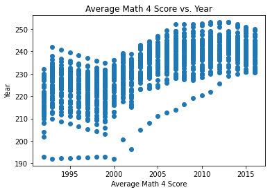

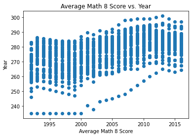

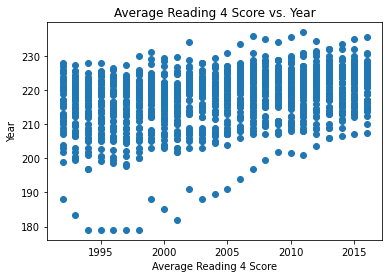

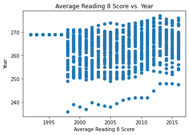

```python
# Import matplotlib and seaborn
import matplotlib.pyplot as plt
import seaborn as sns

# Distribution of grades over time from 1990-2014
plt.figure(0)
plt.scatter(data["YEAR"], data["AVG_MATH_4_SCORE"])
plt.title("Average Math 4 Score vs. Year")
plt.xlabel("Average Math 4 Score")
plt.ylabel("Year")
plt.figure(1)
plt.scatter(data["YEAR"], data["AVG_MATH_8_SCORE"])
plt.title("Average Math 8 Score vs. Year")
plt.xlabel("Average Math 8 Score")
plt.ylabel("Year")
plt.figure(2)
plt.scatter(data["YEAR"], data["AVG_READING_4_SCORE"])
plt.title("Average Reading 4 Score vs. Year")
plt.xlabel("Average Reading 4 Score")
plt.ylabel("Year")
plt.figure(3)
plt.scatter(data["YEAR"], data["AVG_READING_8_SCORE"])
plt.title("Average Reading 8 Score vs. Year")
plt.xlabel("Average Reading 8 Score")
plt.ylabel("Year")
```

Looking at the scatterplots above, it is pretty clear that the average scores are generally increasing across time. One interesting aspect to notice is that the math scores are increasing more than the reading scores, meaning that the factors of this dataset could be effective on the improvement of math scores than reading. This knowledge could come in handy later to see how various factors like expenditure and revenue contribute to math vs. reading scores. However, it looks like there are different trends across different time periods, so we are going to take a closer look at the scores across five different time periods.

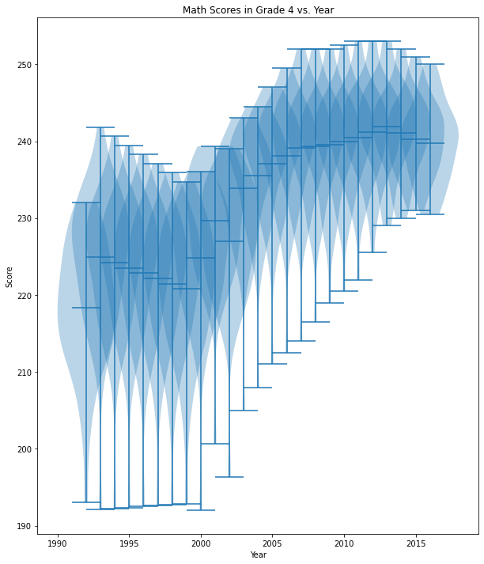

```python
# Violin plot of distribution of math scores in grade 4 across time
fig, ax = plt.subplots(figsize=(10,12))
scores_per_year = []
for year in data["YEAR"].unique():
    cond = data["YEAR"] == year
    arr = data[cond].AVG_MATH_4_SCORE.values
    scores_per_year.append(arr)

# Plot the violin plot
ax.violinplot(scores_per_year,data["YEAR"].unique(),widths=4,showmeans=True)
ax.set_xlabel("Year")
ax.set_ylabel("Score")
ax.set_title("Math Scores in Grade 4 vs. Year")
fig.savefig("violin.png")
```

In the years 1990-2000, the distributions of math scores over time are skewed left and unimodal, meaning that there were more scores above the median of around 220-225. From the years 2000-2005, the medians appear to increase drastically, and in the years after 2005, the medians appear to steadily increase and become more normally distributed, with less variance from the median. Most the the distributions are skewed left and unimodal, escept for the later years around 2012-2016, which becomes more symmetric.

### Visualize Distributions Across Time Periods with Scatterplots

```python
data["YEAR"].unique()
```

```
array([1992, 1993, 1994, 1995, 1996, 1997, 1998, 1999, 2000, 2001, 2002,
       2003, 2004, 2005, 2006, 2007, 2008, 2009, 2010, 2011, 2012, 2013,
       2014, 2015, 2016])
```

There are 25 years included in the dataset, in the range 1992-2016. Thus, we can create five time periods consisting of 5 years each and create a scatterplot for each time period. Of all the columns, we believe intuitively that local revenue can have a signficant impact on scores because a student's performance is often influenced by their local district funding and resources, rather than funding from the whole state, due to the fact that one state can have large dispararities in resources and income depending on the significance of the area.

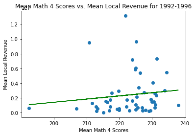

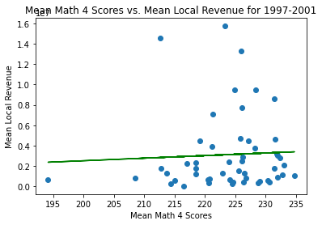

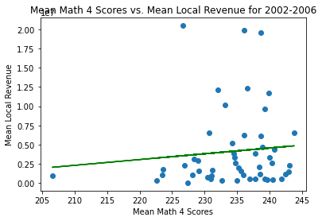

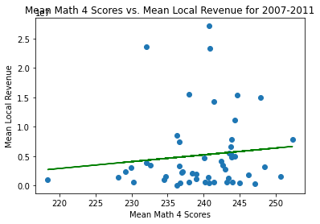

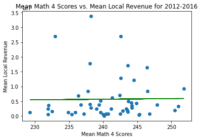

```python
# Import numpy
import numpy as np

# Create bins for each 5 year time period
bin_labels = ["1992-1996","1997-2001","2002-2006","2007-2011","2012-2016"]
data["time_period"] = pd.cut(data["YEAR"], bins=5, right=False, labels=bin_labels)

# For each bin (time period), create a scattterplot for the mean local revenue vs. mean grades.
i = 0
for label in bin_labels:
    label_table = data.drop(data[data["time_period"] != label].index)
    mean_local_rev = label_table.groupby(["STATE"])["LOCAL_REVENUE"].mean() # Get mean revenue
    mean_math_4_score = label_table.groupby(["STATE"])["AVG_MATH_4_SCORE"].mean() # Get mean grades
    mean_local_rev_table = mean_local_rev.to_frame()
    mean_math_4_score_table = mean_math_4_score.to_frame()
    table_labels = mean_math_4_score_table.merge(mean_local_rev_table, how="inner", left_on=["STATE"], right_on=["STATE"])
    table_labels.columns = ["mean_math_4_score","mean_local_rev"]

    # Plot scatterplot
    plt.figure(i)
    i += 1
    plt.title("Mean Math 4 Scores vs. Mean Local Revenue for "+ label)
    plt.xlabel("Mean Math 4 Scores")
    plt.ylabel("Mean Local Revenue")
    plt.scatter(x=table_labels["mean_math_4_score"], y=table_labels["mean_local_rev"])

    # Regression line to show the trend of mean revenue vs. mean grades
    fit = np.polyfit(x=table_labels["mean_math_4_score"], y=table_labels["mean_local_rev"], deg=1)
    plt.plot(table_labels["mean_math_4_score"], fit[0]*table_labels["mean_math_4_score"] +fit[1], color="green")
plt.show()
```

In the time periods 2002-2006 and 2007-2011, the math scores look to be more affected by local revenue, meaning that as local revenue increased, students' score performance tended to increase. This reflected in the interpretations of the violin plotted earlier. One aspect of these scatterplots that is interesting is that in the next 5 years from 2012-2016, the local revenue does not appear to have any effect on the score performance. However, in the violin plot above we saw that the distribution of scores was becoming more symmetric during those years, so other factors could have contributed the student performance. This could also be explained by the amount of online resources that students can access for free to improve their scores as well.

### Connection to real-world law!!

Upon further research, it was found that the [No Child Left Behind (NCLB)](https://www.britannica.com/topic/No-Child-Left-Behind-Act) law in January 2002 was a U.S. federal law aimed at improving public primary and secondary schools and student performance. This law increased accountability in schools across the country, and it resulted in an increase in student performance, which was its goal, by 2014. It ensured that all students, regardless of race or socioeconomic status, would have an equal opportunity for education. This law mandated that all students in a school must be "procifient" by the 2013/2014 school year, which explains the sudden spike in 2002 in student performance, and the higher, more symmetric range and distribution by 2016. This shows that students started performing well, and it displayed that students were more likely to be "procifient" to meet the quota for their state in the later years. Furthermore, this explains why the distribution did not many outlier low scores and it was not skewed left, as schools were mandated to improve all of their students to be "procifient"!

### Looking at revenue and expenditure

```python
data.columns
```

```
Index(['PRIMARY_KEY', 'STATE', 'YEAR', 'TOTAL_REVENUE', 'FEDERAL_REVENUE',
       'STATE_REVENUE', 'LOCAL_REVENUE', 'TOTAL_EXPENDITURE',
       'INSTRUCTION_EXPENDITURE', 'SUPPORT_SERVICES_EXPENDITURE',
       'OTHER_EXPENDITURE', 'CAPITAL_OUTLAY_EXPENDITURE', 'GRADES_PK_G',
       'GRADES_KG_G', 'GRADES_4_G', 'GRADES_8_G', 'GRADES_12_G',
       'GRADES_ALL_G', 'AVG_MATH_4_SCORE', 'AVG_MATH_8_SCORE',
       'AVG_READING_4_SCORE', 'AVG_READING_8_SCORE', 'time_period'],
      dtype='object')
```

We now want to take a deeper dive into revenue and expenditure. As found earlier, local revenue seems to contribute to student score performance. In this dataset, there are four different revenue columns (total, federal, state, and local) and five different expenditure columns (total, instruction, support services, other, and capital outlay). In order to make the columns more applicable to the students enrolled, we found the average for all the revenues and expenditures by dividing them by the number of students enrolled. This allowed us visualize how much revenue and expenditure could be applied per student.

```python
# Get revenues and expenditures per student enrolled
data["AVERAGE_TOTAL_REVENUE"] = data["TOTAL_REVENUE"]/data["GRADES_ALL_G"]
data["AVERAGE_FEDERAL_REVENUE"] = data["FEDERAL_REVENUE"]/data["GRADES_ALL_G"]
data["AVERAGE_STATE_REVENUE"] = data["STATE_REVENUE"]/data["GRADES_ALL_G"]
data["AVERAGE_LOCAL_REVENUE"] = data["LOCAL_REVENUE"]/data["GRADES_ALL_G"]
data["AVERAGE_TOTAL_EXPENDITURE"] = data["TOTAL_EXPENDITURE"]/data["GRADES_ALL_G"]
data["AVERAGE_INSTRUCTION_EXPENDITURE"] = data["INSTRUCTION_EXPENDITURE"]/data["GRADES_ALL_G"]
data["AVERAGE_SUPPORT_SERVICES_EXPENDITURE"] = data["SUPPORT_SERVICES_EXPENDITURE"]/data["GRADES_ALL_G"]
data["AVERAGE_OTHER_EXPENDITURE"] = data["OTHER_EXPENDITURE"]/data["GRADES_ALL_G"]
data["AVERAGE_CAPITAL_OUTLAY_EXPENDITURE"] = data["CAPITAL_OUTLAY_EXPENDITURE"]/data["GRADES_ALL_G"]
```

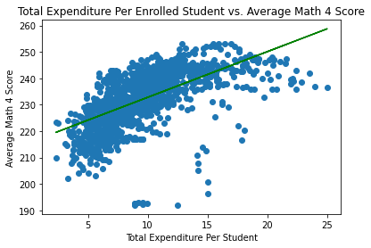

```python
# Create scatter plot of scores vs. total expenditure per student enrolled of all years
plt.title("Total Expenditure Per Enrolled Student vs. Average Math 4 Score")
plt.xlabel("Total Expenditure Per Student")
plt.ylabel("Average Math 4 Score")
plt.scatter(x=data["AVERAGE_TOTAL_EXPENDITURE"], y=data["AVG_MATH_4_SCORE"])
# Regression line to show the trend of total expenditure vs. average math 4 score
fit = np.polyfit(x=data["AVERAGE_TOTAL_EXPENDITURE"], y=data["AVG_MATH_4_SCORE"], deg=1)
plt.plot(data["AVERAGE_TOTAL_EXPENDITURE"], fit[0]*data["AVERAGE_TOTAL_EXPENDITURE"] +fit[1], color="green")
plt.show()
```

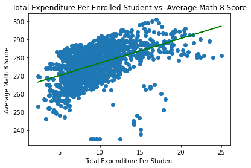

```python
# Create scatter plot of scores vs. total expenditure per student enrolled of all years
plt.title("Total Expenditure Per Enrolled Student vs. Average Math 8 Score")
plt.xlabel("Total Expenditure Per Student")
plt.ylabel("Average Math 8 Score")
plt.scatter(x=data["AVERAGE_TOTAL_EXPENDITURE"], y=data["AVG_MATH_8_SCORE"])
# Regression line to show the trend of total expenditure vs. average math 8 score
fit = np.polyfit(x=data["AVERAGE_TOTAL_EXPENDITURE"], y=data["AVG_MATH_8_SCORE"], deg=1)
plt.plot(data["AVERAGE_TOTAL_EXPENDITURE"], fit[0]*data["AVERAGE_TOTAL_EXPENDITURE"] +fit[1], color="green")
plt.show()
```

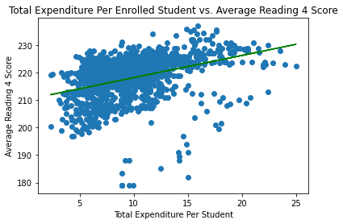

```python
# Create scatter plot of scores vs. total expenditure per student enrolled of all years
plt.title("Total Expenditure Per Enrolled Student vs. Average Reading 4 Score")
plt.xlabel("Total Expenditure Per Student")
plt.ylabel("Average Reading 4 Score")
plt.scatter(x=data["AVERAGE_TOTAL_EXPENDITURE"], y=data["AVG_READING_4_SCORE"])
# Regression line to show the trend of total expenditure vs. average math 8 score
fit = np.polyfit(x=data["AVERAGE_TOTAL_EXPENDITURE"], y=data["AVG_READING_4_SCORE"], deg=1)
plt.plot(data["AVERAGE_TOTAL_EXPENDITURE"], fit[0]*data["AVERAGE_TOTAL_EXPENDITURE"] +fit[1], color="green")
plt.show()
```

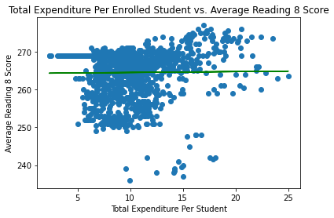

```python
# Create scatter plot of scores vs. total expenditure per student enrolled of all years
plt.title("Total Expenditure Per Enrolled Student vs. Average Reading 8 Score")
plt.xlabel("Total Expenditure Per Student")
plt.ylabel("Average Reading 8 Score")
plt.scatter(x=data["AVERAGE_TOTAL_EXPENDITURE"], y=data["AVG_READING_8_SCORE"])
# Regression line to show the trend of total expenditure vs. average math 8 score
fit = np.polyfit(x=data["AVERAGE_TOTAL_EXPENDITURE"], y=data["AVG_READING_8_SCORE"], deg=1)
plt.plot(data["AVERAGE_TOTAL_EXPENDITURE"], fit[0]*data["AVERAGE_TOTAL_EXPENDITURE"] +fit[1], color="green")
plt.show()
```

The above scatter plots for Math 4, Math 8, and Reading 4 show a clear linear relationship between score performance and the total expenditure per enrolled student. The Reading 8 scores show a weak relationship between the two variables, meaning that the total expenditure likelu does not have much affect on student score performance for Reading 8.

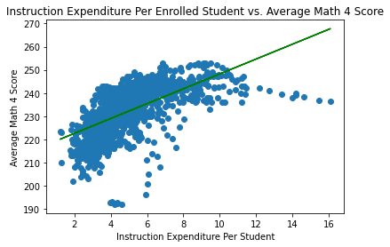

```python
# Create scatter plot of scores vs. instruction expenditure per student enrolled of average math 4 score
plt.title("Instruction Expenditure Per Enrolled Student vs. Average Math 4 Score")
plt.xlabel("Instruction Expenditure Per Student")
plt.ylabel("Average Math 4 Score")
plt.scatter(x=data["AVERAGE_INSTRUCTION_EXPENDITURE"], y=data["AVG_MATH_4_SCORE"])
# Regression line to show the trend of instruction expenditure vs. average math 4 score
fit = np.polyfit(x=data["AVERAGE_INSTRUCTION_EXPENDITURE"], y=data["AVG_MATH_4_SCORE"], deg=1)
plt.plot(data["AVERAGE_INSTRUCTION_EXPENDITURE"], fit[0]*data["AVERAGE_INSTRUCTION_EXPENDITURE"] +fit[1], color="green")
plt.show()
```

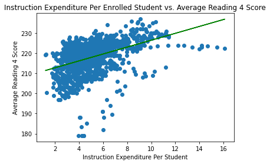

```python
# Create scatter plot of scores vs. instruction expenditure per student enrolled of average reading 4 score
plt.title("Instruction Expenditure Per Enrolled Student vs. Average Reading 4 Score")
plt.xlabel("Instruction Expenditure Per Student")
plt.ylabel("Average Reading 4 Score")
plt.scatter(x=data["AVERAGE_INSTRUCTION_EXPENDITURE"], y=data["AVG_READING_4_SCORE"])
# Regression line to show the trend of instruction expenditure vs. average math 4 score
fit = np.polyfit(x=data["AVERAGE_INSTRUCTION_EXPENDITURE"], y=data["AVG_READING_4_SCORE"], deg=1)
plt.plot(data["AVERAGE_INSTRUCTION_EXPENDITURE"], fit[0]*data["AVERAGE_INSTRUCTION_EXPENDITURE"] +fit[1], color="green")
plt.show()
```

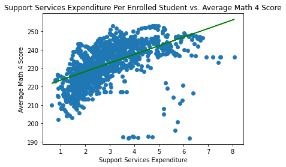

```python
# Create scatter plot of scores vs. support services expenditure of of average math 4 score
plt.title("Support Services Expenditure Per Enrolled Student vs. Average Math 4 Score")
plt.xlabel("Support Services Expenditure")
plt.ylabel("Average Math 4 Score")
plt.scatter(x=data["AVERAGE_SUPPORT_SERVICES_EXPENDITURE"], y=data["AVG_MATH_4_SCORE"])
# Regression line to show the trend of support services expenditure vs. average math 4 score
fit = np.polyfit(x=data["AVERAGE_SUPPORT_SERVICES_EXPENDITURE"], y=data["AVG_MATH_4_SCORE"], deg=1)
plt.plot(data["AVERAGE_SUPPORT_SERVICES_EXPENDITURE"], fit[0]*data["AVERAGE_SUPPORT_SERVICES_EXPENDITURE"] +fit[1], color="green")
plt.show()
```

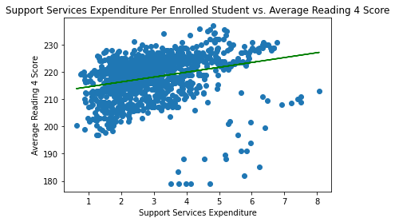

```python
# Create scatter plot of scores vs. support services expenditure of of average math 4 score
plt.title("Support Services Expenditure Per Enrolled Student vs. Average Reading 4 Score")
plt.xlabel("Support Services Expenditure")
plt.ylabel("Average Reading 4 Score")
plt.scatter(x=data["AVERAGE_SUPPORT_SERVICES_EXPENDITURE"], y=data["AVG_READING_4_SCORE"])
# Regression line to show the trend of support services expenditure vs. average math 4 score
fit = np.polyfit(x=data["AVERAGE_SUPPORT_SERVICES_EXPENDITURE"], y=data["AVG_READING_4_SCORE"], deg=1)
plt.plot(data["AVERAGE_SUPPORT_SERVICES_EXPENDITURE"], fit[0]*data["AVERAGE_SUPPORT_SERVICES_EXPENDITURE"] +fit[1], color="green")
plt.show()
```

As we see in the above four scatter plots, it is evident by the regression line for each plot that average scores improve as the expenditure for total, instruction, and support services expenditure increase, which makes sense intuitively. As the funding for education increases, the scores are likely to increase. When specifically looking at math vs reading scores, the total, instruction, and support services expenditure seem to be more useful in math than reading. The slopes of the regression lines for the math scores are higher than those of the reading.

### Visualizing how total revenue is affected by state

Another aspect of the dataset that can be explored is the distributions by state. We can distribute the total revenue by state to see which states have a greater total revenue and money allcoated towards them. This information can allow us to make reasonable conclusions about the data because we know that different states have various resources, populations, number of major cities, and income levels. Therefore, distributions by state would be beneficial to visualize to confirm about our intuitions and be aware of what could impact student score performance.

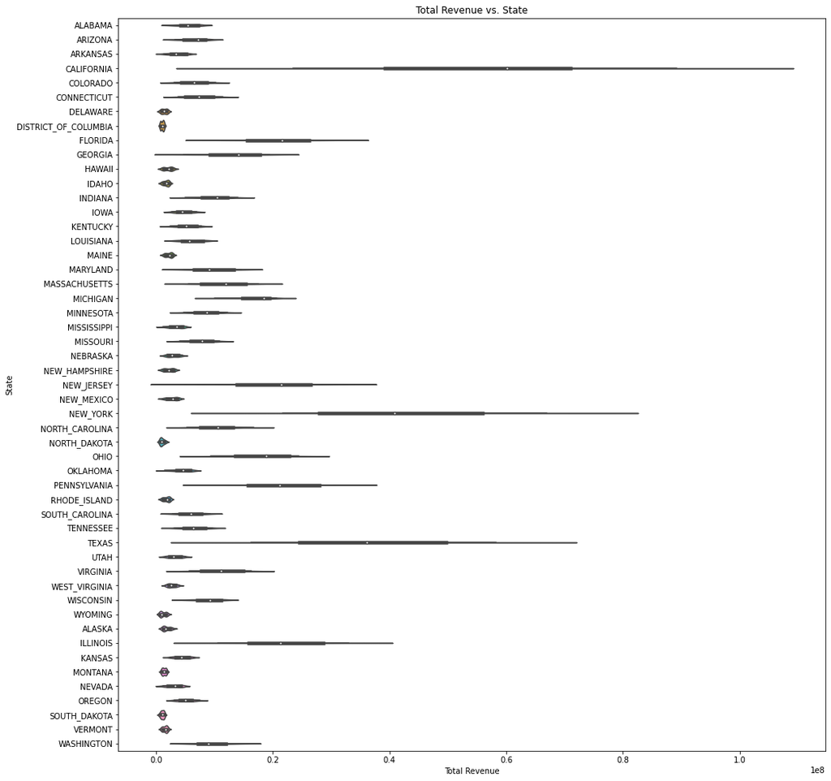

```python
fig, ax = plt.subplots(figsize=(16,17))
sns.violinplot(x="TOTAL_REVENUE", y="STATE", data=data)
ax.set_title("Total Revenue vs. State")
ax.set_xlabel("Total Revenue")
ax.set_ylabel("State")
```

However, we know from prior knowledge that the population of students located in the above states could be greater than average, so we can use the average revenue calulated earlier based on population by dividing the total revenue by the enrollment in all grades for each state. ( Average Revenue = Total Revenue / Enrolled Students )

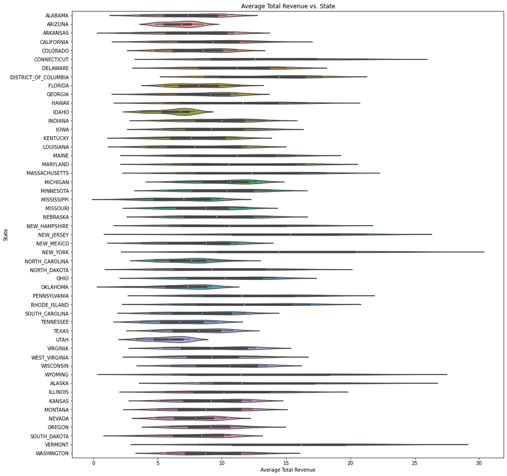

```python
fig, ax = plt.subplots(figsize=(16,17))
sns.violinplot(x="AVERAGE_TOTAL_REVENUE", y="STATE", data=data)
ax.set_title("Average Total Revenue vs. State")
ax.set_xlabel("Average Total Revenue")
ax.set_ylabel("State")
```

The violin plot above supports our intuition that the although some states look like they have a higher total revenue overall, certain states utilize more money per student. For example, states like New York and New Jersey were seen in the previous violin plot, but states like Connecticut, Wyoming, Alaska, and Vermont are shown in this plot as also utilizing their total revenue over less students, meaning that there is more money allocated to each student enrolled in PreK-12 grades.

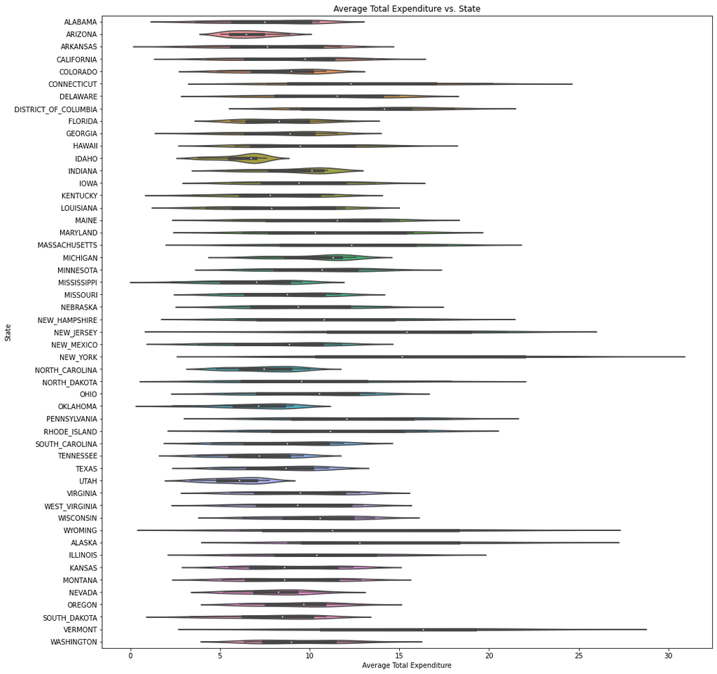

```python
fig, ax = plt.subplots(figsize=(16,17))
sns.violinplot(x="AVERAGE_TOTAL_EXPENDITURE", y="STATE", data=data)
ax.set_title("Average Total Expenditure vs. State")
ax.set_xlabel("Average Total Expenditure")
ax.set_ylabel("State")
```

The violin plot above for total expenditure by state is similar to the total revenue by state violin plot shown earlier. The violin plot above supports our intuition that the although some states look like they have a higher total expenditure overall, certain states utilize more money per student. For example, states like New York and New Jersey were seen previously, but states like Connecticut, Wyoming, Alaska, and Vermont are shown in this plot as also utilizing their total expenditure over less students, meaning that there is more money allocated to each student enrolled in PreK-12 grades.

This is reflective of the [educational spending](https://educationdata.org/public-education-spending-statistics#:~:text=New%20York%20schools%20spend%20the,a%20percentage%20of%20taxpayer%20income.) today in 2022, where all of the listed states continue to be big spenders for public education to this day.

## Predictions with Regression Models

The visualizations above show slight correlations between some of the expenditure and revenue variables and student test scores. We wanted to see how predictive all of the independent variables would be together and decided to try supervised learning regression models.

[This article](https://statisticsbyjim.com/regression/choosing-regression-analysis/) prevides a lot of useful techniques for choosing and evaluating regression models, and it led us to start with an ordinary least squares regression model to see how it would fit the data. We also decided to use the average of all four scoring columns temporarily in our analysis so that we can reason about the models more generally with plans break down the variation between these columns once we can see how a model will fit the averages.

```python
# Get the average of the math and reading scores of both grades 4 and 8.
data["Average_Scores"] = (data["AVG_MATH_4_SCORE"] + data["AVG_MATH_8_SCORE"] + data["AVG_READING_4_SCORE"] + data["AVG_READING_8_SCORE"]) / 4
```

```python
# X is a dataframe with the independent variables. Drop the columns created for the visualizations
# that break down the variables on a per student basis. We will revisit them later, which is why
# they are not dropped from the dataframe entirely.

X = data.drop(columns=['PRIMARY_KEY','STATE','YEAR','AVG_MATH_4_SCORE', 'AVG_MATH_8_SCORE',
       'AVG_READING_4_SCORE', 'AVG_READING_8_SCORE', 'time_period',
       'AVERAGE_TOTAL_REVENUE', 'AVERAGE_FEDERAL_REVENUE',
       'AVERAGE_STATE_REVENUE', 'AVERAGE_LOCAL_REVENUE',
       'AVERAGE_TOTAL_EXPENDITURE', 'AVERAGE_INSTRUCTION_EXPENDITURE',
       'AVERAGE_SUPPORT_SERVICES_EXPENDITURE', 'AVERAGE_OTHER_EXPENDITURE',
       'AVERAGE_CAPITAL_OUTLAY_EXPENDITURE', 'Average_Scores'])
y = data["Average_Scores"]
```

```python
# Import sklearn linear model, metrics, train_test_split, and cross_val_score.
import sklearn.linear_model
import sklearn.metrics as sm
from sklearn.model_selection import train_test_split, cross_val_score

# Create the train and test split.
X_train, X_test, y_train, y_test = train_test_split(X, y, test_size=0.3, random_state=42)

# Building and training the model.
lin_regr = sklearn.linear_model.LinearRegression()
model = lin_regr.fit(X_train, y_train)
pred = model.predict(X_test)

# Calculating the scoring metrics.
print("Accuracy score: "+ str(lin_regr.score(X_test, y_test)))

print("Mean absolute error = ", round(sm.mean_absolute_error(y_test, pred), 2))
print("Mean squared error = ", round(sm.mean_squared_error(y_test, pred), 2))
print("Median absolute error = ", round(sm.median_absolute_error(y_test, pred), 2))
print("Explained variance score = ", round(sm.explained_variance_score(y_test, pred), 2))
print("R2 score = ", round(sm.r2_score(y_test, pred), 2))
```

```
Accuracy score: 0.21750203188962536
Mean absolute error =  5.06
Mean squared error =  43.12
Median absolute error =  4.48
Explained variance score =  0.22
R2 score =  0.22
```

An accuracy score (coefficient of determination) of 0.21750203188962536 is quite low. It does indicate that the model has some predictive power in that it would likely outperform a model of arbitrary guesses, but we wanted to see if we could get stronger results with other types of regression.

[This article](https://towardsdatascience.com/comparative-study-on-classic-machine-learning-algorithms-24f9ff6ab222#:~:text=LR%20vs%20Decision%20Tree%20%3A,be%20having%20better%20average%20accuracy.) explains some of the characteristics of a dataset that might cause linear regression to perform very poorly. It explained that if there is a lot of colinearity in the data, a decision tree would likely be able to provide a more accurate prediction. [This article](https://towardsdatascience.com/multicollinearity-why-is-it-bad-5335030651bf) outlines some of the reasoning. The model is estimating their impact on the result by attempting to control the other variables. When two variables are highly correlated, neither will be shown to have a significant impact because when each is examined the model will realize that it does not explain any variation in the data that the other variable does not also explain.

Ideally, we would be able to significantly reduce the amount of colinearity in the data. However, many of our features are highly correlated by nature (ex: revenue and expenditure). We then discussed the possibility of eliminating the columns that we expect are causing this problem and confirming by examining the [covariance matrix](https://datascienceplus.com/understanding-the-covariance-matrix/). However, we wanted to see how each of these features was individually affecting the outcome, and the reality of our dataset focusing on different areas of expenditure and revenue is that we are expecting for there to be high correlations between nearly all of the features. We instead looked for types of regression that might be less susceptible to colinearity in the data, and found that decision trees are much less affected. [This article](https://towardsdatascience.com/why-feature-correlation-matters-a-lot-847e8ba439c4#:~:text=Multicollinearity%20happens%20when%20one%20predictor,immune%20to%20multicollinearity%20by%20nature%20.) explains how the fact that decision trees are only able to consider one feature for making a decision at each node make high correlations between variables far less of an issue.

### Decision Tree Regressor Model

```python
# Import sklearn metrics, train_test_split, cross_val_score
from sklearn.model_selection import train_test_split, cross_val_score

X_train, X_test, y_train, y_test = train_test_split(X, y, test_size=0.3, random_state=42)
```

```python
# Import DecisionTreeRegressor and GridSearchCV
from sklearn.tree import DecisionTreeRegressor
from sklearn.model_selection import GridSearchCV

dec_tree_reg = DecisionTreeRegressor()

# To choose the best hyperparameters, the model selection procedure we used was Grid Search.
parameters = { 'criterion' : ["mse", "mae"],
             'max_leaf_nodes' : [5,10,20,100,150],
             'max_depth' : [2,8,10,15],
             'min_samples_split' : [3,5,10,20],
             'min_samples_leaf' : [4,10,20] }
dec_tree = GridSearchCV(dec_tree_reg, parameters, cv=10, n_jobs=4)

# Fit model
dec_tree.fit(X_train, y_train)

print("Model selection: " + str(dec_tree.best_params_))

# Predictions
pred = dec_tree.predict(X_test)

print("Test Result:\n===========================================")
print("Accuracy score: "+ str(dec_tree.score(X_test, y_test)))
```

```
Model selection: {'criterion': 'mae', 'max_depth': 10, 'max_leaf_nodes': 100, 'min_samples_leaf': 4, 'min_samples_split': 3}
Test Result:
===========================================
Accuracy score: 0.7278610940601618
```

```python
import sklearn.metrics as sm
print("Mean absolute error = ", round(sm.mean_absolute_error(y_test, pred), 2))
print("Mean squared error = ", round(sm.mean_squared_error(y_test, pred), 2))
print("Median absolute error = ", round(sm.median_absolute_error(y_test, pred), 2))
print("Explained variance score = ", round(sm.explained_variance_score(y_test, pred), 2))
print("R2 score = ", round(sm.r2_score(y_test, pred), 2))
```

```
Mean absolute error =  2.6
Mean squared error =  14.99
Median absolute error =  1.5
Explained variance score =  0.73
R2 score =  0.73
```

```python
# Decision Tree Regressor scores for 10-fold cross validation
cross_val_dec_tree = cross_val_score(dec_tree, X_train, y_train, cv=10)

print("Mean accuracy cross validation for Random Forest Regressor: " + str(cross_val_dec_tree.mean()))
print("Standard error cross validation for Random Forest Regressor: " + str(cross_val_dec_tree.std()))
```

```
Mean accuracy cross validation for Random Forest Regressor: 0.7245973144507065
Standard error cross validation for Random Forest Regressor: 0.07653256013955392
```

We can see that the decision tree regression model significantly outperforms the linear regression model with a score of 0.7245973144507065 compared to 0.21750203188962536.

Upon further [research](https://medium.com/@manepriyanka48/multicollinearity-in-tree-based-models-b971292db140), we found that a random forest regressor model is likely to handle colinearity in the data even better than a decision tree can because the features that have the highest correlations are unlikely to be consistently selected for the same decision tree within the model. We thus decided to try the random forest regressor model to see if we could achieve more accurate predictions.

### Random Forest Regressor Model

```python
# Import RandomForestRegressor and GridSearchCV
from sklearn.ensemble import RandomForestRegressor
from sklearn.model_selection import GridSearchCV

rand_forest_reg = RandomForestRegressor()

# To choose the best hyperparameters, the model selection procedure we used was Grid Search.
parameters = { 'n_estimators' : [2,3,5,9],
             'max_features' : ['log2', 'sqrt', 'auto'],
             'max_depth' : [2,4,6,7,10],
             'min_samples_split' : [2,3,5],
             'min_samples_leaf' : [1,4,8] }
rand_forest = GridSearchCV(rand_forest_reg, parameters, cv=10, n_jobs=4)

# Fit model
rand_forest.fit(X_train, y_train)

print("Model selection: " + str(rand_forest.best_params_))

# Predictions
pred = rand_forest.predict(X_test)

print("Test Result:\n===========================================")
print("Accuracy score: "+ str(rand_forest.score(X_test, y_test)))
```

```
Model selection: {'max_depth': 10, 'max_features': 'auto', 'min_samples_leaf': 1, 'min_samples_split': 3, 'n_estimators': 9}
Test Result:
===========================================
Accuracy score: 0.8326451858944233
```

```python
print("Mean absolute error = ", round(sm.mean_absolute_error(y_test, pred), 2))
print("Mean squared error = ", round(sm.mean_squared_error(y_test, pred), 2))
print("Median absolute error = ", round(sm.median_absolute_error(y_test, pred), 2))
print("Explained variance score = ", round(sm.explained_variance_score(y_test, pred), 2))
print("R2 score = ", round(sm.r2_score(y_test, pred), 2))
```

```
Mean absolute error =  2.26
Mean squared error =  9.22
Median absolute error =  1.66
Explained variance score =  0.83
R2 score =  0.83
```

```python
# Random Forest Regressor scores for 10-fold cross validation
cross_val_rand_forest = cross_val_score(rand_forest, X_train, y_train, cv=10)

print("Mean accuracy cross validation for Random Forest Regressor: " + str(cross_val_rand_forest.mean()))
print("Standard error cross validation for Random Forest Regressor: " + str(cross_val_rand_forest.std()))
```

```
Mean accuracy cross validation for Random Forest Regressor: 0.8414783974091178
Standard error cross validation for Random Forest Regressor: 0.03870388093830524
```

We can see that the random forest regressor model results in a significantly higher R2 Score/Accuracy than the decision tree and linear regression models. Since many of our independent variables are given in total amounts of money, we wanted to see how the model would be affected if these quantities were instead represented as the amount of money divided by the student enrollment, indicating the theoretical amount of funds that could be dedicated to each student.

### Model with Variables Divided by the Number of Students

```python
X = data.drop(columns=['PRIMARY_KEY','STATE','YEAR','TOTAL_REVENUE', 'FEDERAL_REVENUE',
       'STATE_REVENUE', 'LOCAL_REVENUE', 'TOTAL_EXPENDITURE',
       'INSTRUCTION_EXPENDITURE', 'SUPPORT_SERVICES_EXPENDITURE',
       'OTHER_EXPENDITURE', 'CAPITAL_OUTLAY_EXPENDITURE', 'AVG_MATH_4_SCORE', 'AVG_MATH_8_SCORE',
       'AVG_READING_4_SCORE', 'AVG_READING_8_SCORE', 'time_period', 'Average_Scores'])
y = data["Average_Scores"]
```

```python
# Split data into training and test sets for new model with averaged columns
X_train, X_test, y_train, y_test = train_test_split(X, y, test_size=0.3, random_state=42)
```

```python
rand_forest_reg_avg = RandomForestRegressor()

# To choose the best hyperparameters, the model selection procedure we used was Grid Search.
parameters = { 'n_estimators' : [2,3,5,9],
             'max_features' : ['log2', 'sqrt', 'auto'],
             'max_depth' : [2,4,6,7,10],
             'min_samples_split' : [2,3,5],
             'min_samples_leaf' : [1,4,8] }
rand_forest_avg = GridSearchCV(rand_forest_reg_avg, parameters, cv=10, n_jobs=4)

# Fit model
rand_forest_avg.fit(X_train, y_train)

print("Model selection: " + str(rand_forest_avg.best_params_))

# Predictions
pred = rand_forest_avg.predict(X_test)

print("Test Result:\n===========================================")
print("Accuracy score: "+ str(rand_forest_avg.score(X_test, y_test)))
```

```
Model selection: {'max_depth': 10, 'max_features': 'sqrt', 'min_samples_leaf': 1, 'min_samples_split': 3, 'n_estimators': 9}
Test Result:
===========================================
Accuracy score: 0.7880804478945861
```

```python
print("Mean absolute error = ", round(sm.mean_absolute_error(y_test, pred), 2))
print("Mean squared error = ", round(sm.mean_squared_error(y_test, pred), 2))
print("Median absolute error = ", round(sm.median_absolute_error(y_test, pred), 2))
print("Explained variance score = ", round(sm.explained_variance_score(y_test, pred), 2))
print("R2 score = ", round(sm.r2_score(y_test, pred), 2))
```

```
Mean absolute error =  2.64
Mean squared error =  11.68
Median absolute error =  2.1
Explained variance score =  0.79
R2 score =  0.79
```

```python
# Random Forest Regressor average scores for 10-fold cross validation
cross_val_rand_forest_avg = cross_val_score(rand_forest_avg, X_train, y_train, cv=10)

print("Mean accuracy cross validation for Random Forest Regressor: " + str(cross_val_rand_forest_avg.mean()))
print("Standard error cross validation for Random Forest Regressor: " + str(cross_val_rand_forest_avg.std()))
```

```
Mean accuracy cross validation for Random Forest Regressor: 0.7944061504778915
Standard error cross validation for Random Forest Regressor: 0.038839006580867474
```

Interestingly, accounting for the number of students for the independent variables slightly lowered the accuracy of the model. One possible reason is that some of the states with the [lowest populations](https://www.50states.com/population-by-state/) also are known to be some of the states with the [lowest performing public school systems](https://worldpopulationreview.com/state-rankings/public-school-rankings-by-state).

When we divide by the number of students enrolled, we are lowering the various expenditure and revenue values by far less in these states than in highly-populated states. This is likely not a coincidence since [students in rural areas are known to have the lowest levels of educational opportunity when compared to students in urban and suburban areas](https://www.brookings.edu/blog/brown-center-chalkboard/2022/07/13/what-is-the-status-of-educational-opportunity-in-rural-america/).

We considered sticking with the model that divides the independent variables by the number of students even though it has slightly worse metrics because we wanted the model to be able to predict student test scores directly based on the features in our dataset and not by estimating the demography of each state. However, we ultimately decided to return to the model with the original columns because we came to the conclusion that predictions based on population size and revenue are within the realm of our analysis, and it could be argued that these are the factors driving the achievement gap in rural areas rather than the fact that the area is rural leading to decreases in these factors, as suggested by [this study](https://jrre.psu.edu/sites/default/files/2019-08/20-14.pdf) in the Journal of Research in Rural Education.

```python
# Dropping the columns divided by the number of students for this model.
data = data.drop(columns=[
       'AVERAGE_TOTAL_REVENUE', 'AVERAGE_FEDERAL_REVENUE',
       'AVERAGE_STATE_REVENUE', 'AVERAGE_LOCAL_REVENUE',
       'AVERAGE_TOTAL_EXPENDITURE', 'AVERAGE_INSTRUCTION_EXPENDITURE',
       'AVERAGE_SUPPORT_SERVICES_EXPENDITURE', 'AVERAGE_OTHER_EXPENDITURE',
       'AVERAGE_CAPITAL_OUTLAY_EXPENDITURE', 'Average_Scores'])
```

### Math vs Reading scores

The earlier visuals examining the relationship between various independent variables and the four individual test score columns seem to be more similar for the scores broken down by subject rather than grade level. That is to say the distributions of 4th and 8th grade math scores seem to be closer to one another than the distributions of 4th grade math and reading scores and separately 8th grade math and reading scores. The same holds true for the relationship between 4th and 8th grade reading scores. We thus decided to group the scores by subject and create separate random forest models for each to see how they will differ. We are especially interested in finding out if one subject is easier to predict from the independent variables than the other because that would suggest that the former is more affected by revenue and expenditure than the latter.

#### Math

```python
# Taking the average of 4th and 8th grade for math and reading scores.
data["AVG_MATH_SCORE"] = (data["AVG_MATH_4_SCORE"] + data["AVG_MATH_8_SCORE"]) / 2
data["AVG_READING_SCORE"] = (data["AVG_READING_4_SCORE"] + data["AVG_READING_8_SCORE"]) / 2
```

```python
# X: the independent variables for the model - dropping the columns
X = data.drop(columns=['PRIMARY_KEY','STATE','YEAR','AVG_MATH_4_SCORE', 'AVG_MATH_8_SCORE',
       'AVG_READING_4_SCORE', 'AVG_READING_8_SCORE', 'time_period', 'AVG_MATH_SCORE', 'AVG_READING_SCORE'])
# y: the dependent variable of average math score.
y = data["AVG_MATH_SCORE"]
```

```python
# Split data into training and test sets for new model for math scores.
X_train, X_test, y_train, y_test = train_test_split(X, y, test_size=0.3, random_state=42)
```

```python
rand_forest_reg_math = RandomForestRegressor()

# To choose the best hyperparameters, the model selection procedure we used was Grid Search.
parameters = { 'n_estimators' : [2,3,5,9],
             'max_features' : ['log2', 'sqrt', 'auto'],
             'max_depth' : [2,4,6,7,10],
             'min_samples_split' : [2,3,5],
             'min_samples_leaf' : [1,4,8] }
rand_forest_math = GridSearchCV(rand_forest_reg_math, parameters, cv=10, n_jobs=4)

# Fit model
rand_forest_math.fit(X_train, y_train)

print("Model selection: " + str(rand_forest_math.best_params_))

# Predictions
pred = rand_forest_math.predict(X_test)

print("Test Result:\n===========================================")
print("Accuracy score: "+ str(rand_forest_math.score(X_test, y_test)))
```

```
Model selection: {'max_depth': 10, 'max_features': 'auto', 'min_samples_leaf': 1, 'min_samples_split': 2, 'n_estimators': 9}
Test Result:
===========================================
Accuracy score: 0.8327524829777176
```

```python
print("Mean absolute error = ", round(sm.mean_absolute_error(y_test, pred), 2))
print("Mean squared error = ", round(sm.mean_squared_error(y_test, pred), 2))
print("Median absolute error = ", round(sm.median_absolute_error(y_test, pred), 2))
print("Explained variance score = ", round(sm.explained_variance_score(y_test, pred), 2))
print("R2 score = ", round(sm.r2_score(y_test, pred), 2))
```

```
Mean absolute error =  2.92
Mean squared error =  16.68
Median absolute error =  2.02
Explained variance score =  0.83
R2 score =  0.83
```

```python
# Random Forest Regressor average math scores for 10-fold cross validation
cross_val_rand_forest_math = cross_val_score(rand_forest_math, X_train, y_train, cv=10)

print("Mean accuracy cross validation for Random Forest Regressor: " + str(cross_val_rand_forest_math.mean()))
print("Standard error cross validation for Random Forest Regressor: " + str(cross_val_rand_forest_math.std()))
```

```
Mean accuracy cross validation for Random Forest Regressor: 0.8174206404943345
Standard error cross validation for Random Forest Regressor: 0.03922021601052989
```

#### Reading

```python
# y: the dependent variable of average reading score.
y = data["AVG_READING_SCORE"]
X_train, X_test, y_train, y_test = train_test_split(X, y, test_size=0.3, random_state=42)
```

```python
rand_forest_reg_reading = RandomForestRegressor()

# To choose the best hyperparameters, the model selection procedure we used was Grid Search.
parameters = { 'n_estimators' : [2,3,5,9],
             'max_features' : ['log2', 'sqrt', 'auto'],
             'max_depth' : [2,4,6,7,10],
             'min_samples_split' : [2,3,5],
             'min_samples_leaf' : [1,4,8] }
rand_forest_reading = GridSearchCV(rand_forest_reg_reading, parameters, cv=10, n_jobs=4)

# Fit model
rand_forest_reading.fit(X_train, y_train)

print("Model selection: " + str(rand_forest_reading.best_params_))

# Predictions
pred = rand_forest_reading.predict(X_test)

print("Test Result:\n===========================================")
print("Accuracy score: "+ str(rand_forest_reading.score(X_test, y_test)))
```

```
Model selection: {'max_depth': 10, 'max_features': 'auto', 'min_samples_leaf': 1, 'min_samples_split': 2, 'n_estimators': 9}
Test Result:
===========================================
Accuracy score: 0.7365284108293568
```

```python
print("Mean absolute error = ", round(sm.mean_absolute_error(y_test, pred), 2))
print("Mean squared error = ", round(sm.mean_squared_error(y_test, pred), 2))
print("Median absolute error = ", round(sm.median_absolute_error(y_test, pred), 2))
print("Explained variance score = ", round(sm.explained_variance_score(y_test, pred), 2))
print("R2 score = ", round(sm.r2_score(y_test, pred), 2))
```

```
Mean absolute error =  2.27
Mean squared error =  10.01
Median absolute error =  1.59
Explained variance score =  0.74
R2 score =  0.74
```

```python
# Random Forest Regressor average reading scores for 10-fold cross validation
cross_val_rand_forest_reading = cross_val_score(rand_forest_reading, X_train, y_train, cv=10)

print("Mean accuracy cross validation for Random Forest Regressor: " + str(cross_val_rand_forest_reading.mean()))
print("Standard error cross validation for Random Forest Regressor: " + str(cross_val_rand_forest_reading.std()))
```

```
Mean accuracy cross validation for Random Forest Regressor: 0.7860614373934955
Standard error cross validation for Random Forest Regressor: 0.0666804674187269
```

The random forest model does seem to make more accurate predictions for math scores than reading scores. One possibility is that math scores are simply more malleable to factors like instructional expenditure and revenue, as supported by [this study](https://econweb.ucsd.edu/~gdahl/papers/children-and-EITC.pdf), but we wanted to figure out if this observed difference is significant enough to make an argument.

## Hypothesis Testing

We then wanted to do a hypothesis test to see if the differences we are seeing between prediction quality for reading and math are statistically significant. The goal is to see if one of these scores can be more accurately predicted from factors like expenditure and revenue than the other. We decided to compare the resulting distributions from the 10-fold cross validation. The null hypothesis is that there is no difference between the prediction quality for math and reading scores, and the alternative hypothesis is that there is a statistically significant difference.

```python
from scipy.stats import ttest_ind_from_stats

# Inputting the means and standard deviations from the cross validation results above.
ttest_ind_from_stats(mean1=cross_val_rand_forest_reading.mean(), std1=cross_val_rand_forest_reading.std(), nobs1=10,
                     mean2=cross_val_rand_forest_math.mean(), std2=cross_val_rand_forest_math.std(), nobs2=10)
```

```
Ttest_indResult(statistic=-1.2818898726958272, pvalue=0.21614726055895933)
```

With a p-value of 0.21614726055895933, we can not reject the null hypothesis that there is no difference in the ability of a random forest model to predict math and reading scores.

## Conclusion/Insights

Although we were not able to conclude that there is a statistically significant difference in the ability of a random forest model to predict math versus reading scores, we were still able to achieve a coefficient of determination of 0.8326451858944233 for the model that predicted the average of all four scores.

These findings suggest that state revenue and expenditure are strongly correlated to student test scores. Whether or not these factors are directly causal or are simply correlated with the true causal factors is still yet to be determined, but regardless, the model has still demonstrated that student test scores can be predicted relatively well from basic information on state spending without any other insights about the students or their educational experiences.

It is saddening to see how much of student outcomes seem to be predetermined by monetary factors outside of their control, and this analysis is not even considering the inequalities that exist within states. However, the importance and impact of educational spending does suggest that increasing the amount of money put into education has the potential to seriously reduce the achievement gap between states.

It is also interesting to revisit what was found earlier during data analysis and visualizations: the [No Child Left Behind (NCLB)](https://www.britannica.com/topic/No-Child-Left-Behind-Act) law in January 2002, which was a U.S. federal law aimed at improving public primary and secondary schools and student performance. This law increased accountability in schools across the country, and it resulted in an increase in student performance, which was its goal, by 2014. It ensured that all students, regardless of race or socioeconomic status, would have an equal opportunity for education. This law mandated that all students in a school must be "procifient" by the 2013/2014 school year, which explains the sudden spike in 2002 in student performance and the higher distribution by 2016. This shows that schools were following the law and commiting more resources to make all of their students "procifient" to meet the quota for their state. The success of this intervention suggests that federal government aid and policy does have the potential to be effective in this area.

There are two main options we see moving forward. At the state level, more state revenue could be dedicated to educational purposes in states that are particularly struggling. On the federal level, the Department of Education could allocate more resources and funding to states and regions that seem to be falling behind or lacking in educational resources. Ultimately, whatever intervention strategy is decided upon by federal and state stakeholders in reducing the achievement gap in student scores is of the utmost importance and deserves all of the necessary attention, funds, and effort.